```python
import numpy as np
import scipy
from scipy.io.wavfile import read
import matplotlib.pyplot as plt
from IPython.display import Audio
import librosa, librosa.display
import pandas as pd
plt.rcParams['figure.figsize'] = (8, 4)
from scipy import signal
from librosa import feature, frames_to_time, autocorrelate, clicks
from librosa.feature import zero_crossing_rate, mfcc, spectral_bandwidth, spectral_centroid, spectral_rolloff, chroma_stft
```

# HW 3: STFT, Features, and Regression (15 points)

For each markdown cell, add a cell (or cells) of code below. Reminders:

- This is an individual assignment.
- If you use GenAI tools to assist you with your homework, remember to fill out the GenAI Usage Statement at the bottom of the notebook. Even if you use GenAI, you should not be directly copying the code.
- You may only use functions/packages we have discussed in class

Read in the following files from your "audio" folder.

- /audio/country.00000.wav
- /audio/hiphop.00000.wav

Ensure that amplitudes are normalized to between -1 and 1.

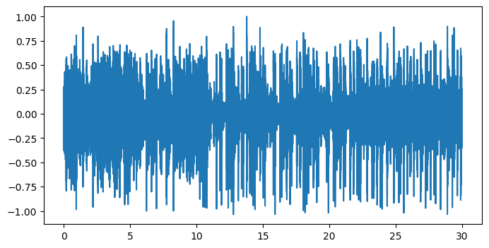

```python
(fs_c, c) = read('../Audio/country.00000.wav')
dur_c = c.size/fs_c
time_c = np.arange(0, dur_c, 1/fs_c)
cnorm = c/np.abs(c.max())

(fs_h, h) = read('../Audio/hiphop.00000.wav')
dur_h = h.size/fs_h
time_h = np.arange(0, dur_h, 1/fs_h)
hnorm = h/np.abs(h.max())

plt.plot(time_h, hnorm)
```

## Part 1: STFT parameters and visualization (6 points)

#### Write your own STFT (3 points)

Write your own STFT function that will output a 2D matrix with shape (num_frames, num_bins), where each row contains the DFT of a single frame.

- Use a hop size equal to half the frame size (i.e., hop_size = frame_size // 2) so that frames overlap by 50%, and you should apply a hanning window to each frame (you may use `np.hanning()` for this.)
- The user should be able to vary the size of the frame (leave hop_size fixed at 50%).

*Note: You should use the built in numpy FFT function (instead of your DFT). This means you will have to work in powers of 2!*

```python
import numpy as np

def my_stft(audio_input, frame_size, fs=44100):

    # Define frame_length (should be power of two based on input frame_size)
    frame_length = 2 ** int(np.round(np.log2(frame_size)))

    # Define hop size is half the frame size
    hop_length = frame_length // 2

    # Define number of frames (m) we can extract with 50% overlap based on the total length of our signal
    # If the signal does not fit an integer number of frames, truncate
    n_mbins = (len(audio_input) - frame_length) // hop_length + 1

    # Define total number of frequency bins
    n_kbins = frame_length // 2 + 1

    # Pre-allocate matrix for STFT. Remember it should be structured as [time_frames, frequency_bins]
    stft_matrix = np.zeros([n_mbins, n_kbins], dtype=complex)

    # Define window
    window = np.hanning(frame_length)

    # Iterate through signal by frame
    for m in range(n_mbins):
        # index into the frame, apply window, apply fft over the frame, store in matrix
        start = m * hop_length
        frame = audio_input[start : start + frame_length]
        stft_matrix[m, :] = np.fft.rfft(frame * window)[:n_kbins]

    # create freq axis for plotting
    freqs = np.fft.rfftfreq(frame_length, d=1/fs)


    return stft_matrix, freqs
```

#### Apply your STFT function

Apply your STFT function to the audio files listed above (country and hiphop)

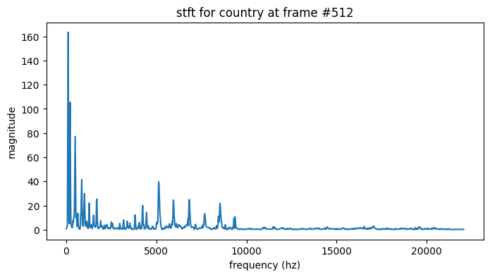

```python
# your code here

c_stft, c_freqs = my_stft(cnorm, 2048)
h_stft, h_freqs = my_stft(hnorm, 2048)

# c_stft
plt.plot(c_freqs, np.abs(c_stft[512]))
plt.ylabel('magnitude')
plt.xlabel('frequency (hz)')
plt.title('stft for country at frame #512')
```

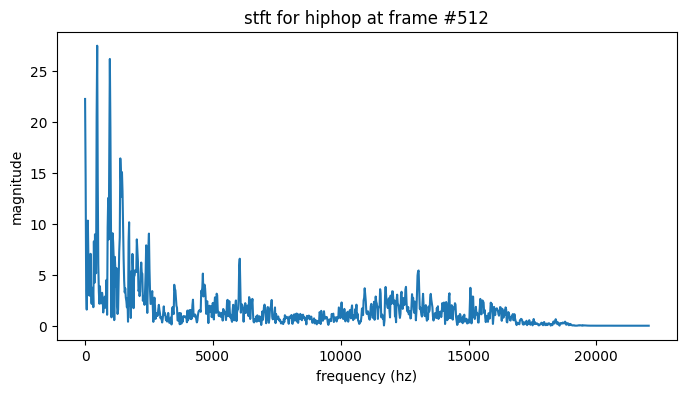

```python
plt.plot(h_freqs, np.abs(h_stft[512]))
plt.ylabel('magnitude')
plt.xlabel('frequency (hz)')
plt.title('stft for hiphop at frame #512')
```

#### Write your own spectrogram function (3 points)

Write your own spectrogram function (using `plt.pcolormesh()`) called `plot_spectrogram()` that takes the complex-valued STFT output from your above function, and the sampling rate, and plots a magnitude spectrogram in decibels.

The axes should be properly labeled (time on x-axis, Frequency on y-axis).

*Note: audio processing workflows and dataframe logic in general in Python commonly use rows = time. However, several plotting functions like pcolormesh() annoyingly expect rows = frequency and columns = time. Therefore, we simply add a step to 'transpose' our 2d array or matrix in our code below.*

```python
# your code here
def plot_spectrogram(stft_matrix, frame_size, sampling_rate):

    # Take magnitude and convert to decibels
    magnitude = np.abs(stft_matrix).T  # Transpose so rows = frequencies
    magnitude_db = 20 * np.log10(magnitude + 1e-6)  # avoid log(0)

    frame_length = 2 ** int(np.round(np.log2(frame_size)))

    # Time and frequency axes
    num_frames = stft_matrix.shape[0] # total number of frames
    hop_size = frame_length // 2# recall it was 50% of the frame size
    duration = (num_frames * hop_size) / sampling_rate   # find duration

    # Make a time axis by taking the total duration and dividing the timeline according to the number of frames:
    time_axis = np.linspace(0, duration, num_frames)
    # Ditto for frequency axis according to the number of bins
    freq_axis = np.linspace(0, sampling_rate, stft_matrix.shape[1])

    # Plot only up to Nyquist frequency by indexing your magnitude vector
    plt.pcolormesh(time_axis, freq_axis, magnitude_db)
    plt.xlabel('time (s)')
    plt.ylabel('frequency (hz)')
    plt.title('spectrogram')
    plt.show()
```

Plot the spectrogram of the country and hiphop audio files

[figure not shown]

```python
plot_spectrogram(c_stft, 2048, fs_c)
```

[figure not shown]

```python
plot_spectrogram(h_stft, 2048, fs_h)
```

## Part 2: Feature Extraction (4 points)

We will perform feature extraction and compare the two audio files above.

Extract the following features for each file (you may use librosa functions):

- RMSE
- Spectral Centroid
- Spectral Flux
- ZCR

For each feature:

- graph the results of each feature
- briefly describe what the feature might tell us perceptually
- briefly describe whether or not this might be a useful feature for classification (based on the graphs)

1 point for each correct feature calculation and associated explanation/reasoning

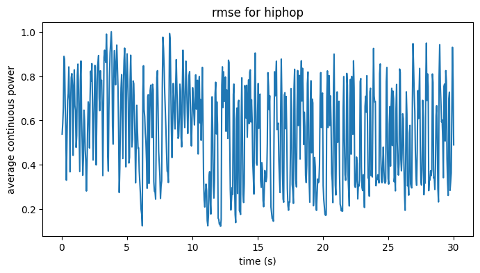

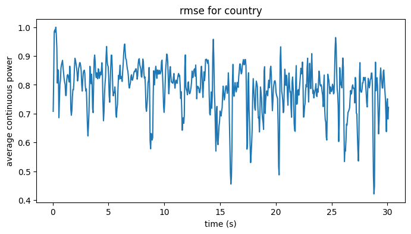

```python
def rmse(data, name, fs, frame_length, hop_length):
    energy = np.array([])
    for i in range(0,len(data),hop_length): #iterate through data frame by frame, shifting by factor of hop_length
        e_i = sum(abs(data[i:i+frame_length]**2)) #sum across samples of each frame
        energy = np.append(energy,e_i)

    _rmse = np.array([])
    for i in range (0,len(data),hop_length):
        rms_i = np.sqrt(np.mean(abs(data[i:i+frame_length]**2)))
        _rmse = np.append(_rmse,rms_i)
    name = name
    frames = range(1,len(energy)+1)
    t = frames_to_time(frames, fs, hop_length=hop_length)
    plt.plot(t,_rmse/_rmse.max(), label='RMSE')
    plt.title('rmse for ' + f'{name}')
    plt.xlabel('time (s)')
    plt.ylabel('average continuous power')
    plt.show()


rmse(hnorm, 'hiphop', fs_h, 2048, 1024)
# RMSE for hiphop

rmse(cnorm, 'country', fs_c, 2048, 1024)
# RMSE for country


# plotting
```

Your RMSE explantion here!

RMSE is a common measure of the intensity of a signal. It calculates the average, or continuous, power of a signal.

[figure not shown]

```python
# Spectral Centroid for hiphop
h = spectral_centroid(y=hnorm.astype(float), sr=fs_h)
# Spectral Centroid for country
c = spectral_centroid(y=cnorm.astype(float), sr=fs_c)
# plotting

plt.figure(figsize = (14,10))
plt.subplot(2,1,1)
plt.semilogy(h[0])
plt.title('spectral centroid over time for hiphop')
plt.ylabel('hz')
plt.xlabel('time(s)')
plt.subplot(2,1,2)
plt.semilogy(c[0])
plt.title('spectral centroid over time for country')
plt.ylabel('hz')
plt.xlabel('time(s)')
```

Your centroid explanation here!

Spectral centroid refers to the 'gravitational center' or centroid of spectral energy. High values correpsond with an abundance of high frequencies and 'nasal' sounds, whereas low values correspond with an abundance of low frequencies and 'dull' sounds. The value is essentially a weighted average of the frequencies present in the signal at a given time.

```
(0.0, 20.0)
```

[figure not shown]

```python
# spectral flux for hiphop
frame_length = 2048
hop_length = 1024

mag_h = np.abs(h_stft)
diff_h = np.diff(mag_h, axis=1)
flux_h = np.sum(diff_h**2, axis=0)
flux_h = np.concatenate(([0], flux_h))

frames_h = range(1, len(flux_h)+1)
t_h = frames_to_time(frames_h, sr=fs_h, hop_length=hop_length)
# spectral flux for country
mag_c = np.abs(c_stft)
diff_c = np.diff(mag_c, axis=1)
flux_c = np.sum(diff_c**2, axis=0)
flux_c = np.concatenate(([0], flux_c))

frames_c = range(1, len(flux_c)+1)
t_c = frames_to_time(frames_c, sr=fs_c, hop_length=hop_length)
# plotting

plt.figure(figsize = (8,10))
plt.subplot(2,1,1)
plt.plot(t_h, flux_h)
plt.title('spectral flux over time for hiphop')
plt.ylabel('flux')
plt.xlabel('time(s)')
plt.xlim(0,20)
plt.subplot(2,1,2)
plt.plot(t_c, flux_c)
plt.title('spectral flux for country')
plt.ylabel('flux')
plt.xlabel('time(s)')
plt.xlim(0, 20)
```

Your spectral flux explanation here!

Spectral flux is a signal's spectral time-variance, meaning the amount of change in a signal's spectral shape(changes in the signals's frequency and amplitude components over time).

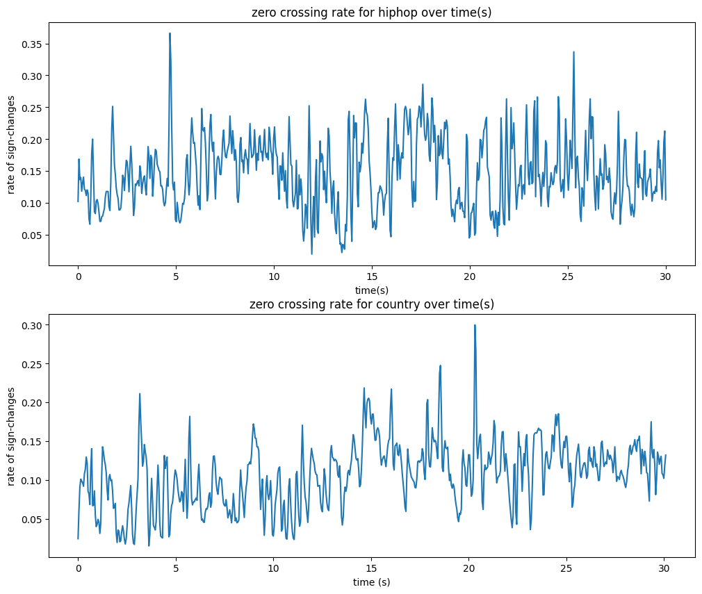

```python
# ZCR for hiphop

zh = zero_crossing_rate(hnorm.astype(float), hop_length=1024)
hx = np.linspace(0, len(hnorm)/fs_h,len(zh[0]))
# ZCR for country

zc = zero_crossing_rate(cnorm.astype(float), hop_length=1024)
cx = np.linspace(0, len(cnorm)/fs_c,len(zc[0]))

# plotting

plt.figure(figsize=(12,10))
plt.subplot(2, 1, 1)
plt.plot(hx, zh[0])
plt.title('zero crossing rate for hiphop over time(s)')
plt.ylabel('rate of sign-changes')
plt.xlabel('time(s)')
plt.subplot(2, 1, 2)
plt.plot(cx, zc[0])
plt.title('zero crossing rate for country over time(s)')
plt.ylabel('rate of sign-changes')
plt.xlabel('time (s)')
```

Your ZCR explanation here!

Zero crossing rate is the rate of sign-changes of the signal during an audio frame or the amount of times the signal crosses zero from positive to negative (and vice-versa) divided by tthe length of the frame.

## Part 3: Binomial Logistic Regression (5 points)

Like in activity 7, you will build a binomial classifier with logistic regression. You will use the GTZAN genre dataset 'features_30_sec.csv' this time to classify hiphop vs country music.

```python
data = pd.read_csv('../Datasets/features_30_sec.csv')
```

### Explore the data and select your features (3 points)

Use graphing and correlation techniques to determine 5 features you will use for your classification.

You must at a minimum create 1 bar graph and 1 box plot in addition to computing the correlation between the features you select.

Construct your Pandas dataframe for your chosen features. Remember you may want to do some scaling and normalization.

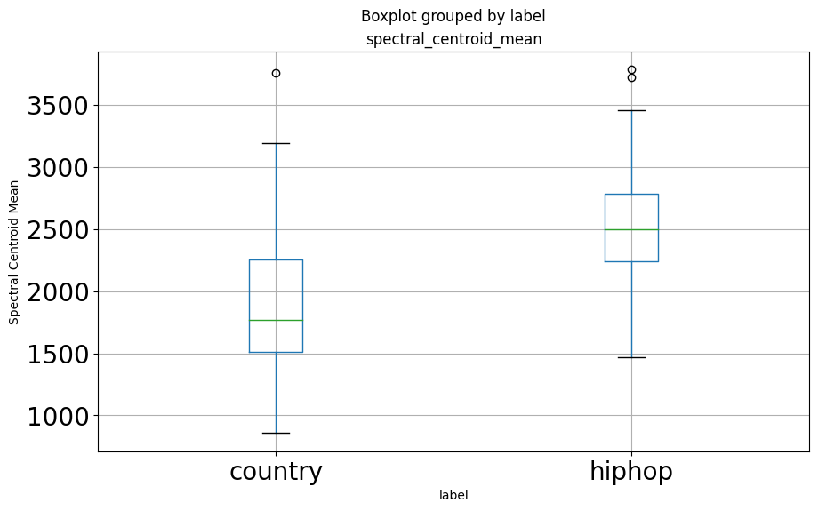

```python
kept_columns = ['label',
                'rms_mean', 'spectral_centroid_mean', 'spectral_bandwidth_mean',
                'harmony_mean', 'zero_crossing_rate_mean']
data = data[kept_columns]
# data.columns
genres = ['hiphop', 'country']
data = data[data['label'].isin(genres)]

# plt.figure(figsize=(10,6))
data.boxplot(column="spectral_centroid_mean", by="label", figsize=(10,6),fontsize=20)
plt.ylabel("Spectral Centroid Mean")
plt.show()
```

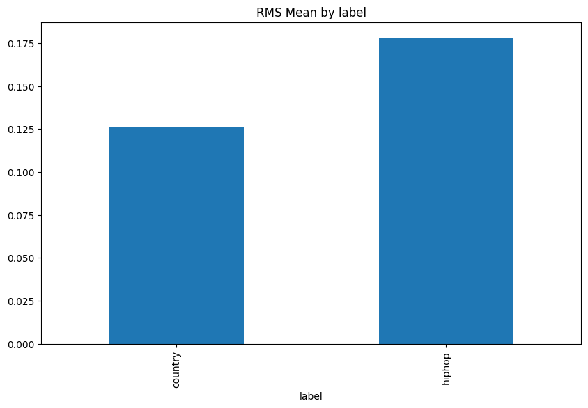

```python
genre_rms = data.groupby('label')['rms_mean'].mean()
genre_rms.plot.bar(figsize=(10, 6), title='RMS Mean by label')
```

```python
genre = pd.get_dummies(data['label'],drop_first=True)
data = pd.concat([genre, data.drop('label', axis=1)], axis=1)
data.head()
```

|  | hiphop | rms_mean | spectral_centroid_mean | spectral_bandwidth_mean | harmony_mean | zero_crossing_rate_mean |
| --- | --- | --- | --- | --- | --- | --- |
| 200 | 0 | 0.248418 | 2797.844810 | 2847.551887 | -0.000135 | 0.107205 |
| 201 | 0 | 0.230516 | 2938.155358 | 2839.657689 | -0.000067 | 0.126988 |
| 202 | 0 | 0.146586 | 2308.673365 | 2618.607096 | -0.000238 | 0.074162 |
| 203 | 0 | 0.204364 | 2174.033869 | 2280.888606 | -0.000157 | 0.102564 |
| 204 | 0 | 0.209498 | 2966.086095 | 2848.106749 | -0.000094 | 0.124161 |

```python
from sklearn import preprocessing
```

```python
scaler = preprocessing.StandardScaler()
scaled_data = scaler.fit_transform(data)
```

### Train/Test Split

Use sklearn to split your data into testing and training sets. Remember you will need to define your categories, predictors, and test size. Use 30% test size.

```python
from sklearn.linear_model import LogisticRegression
from sklearn.model_selection import train_test_split
```

```python
categories = scaled_data[:,1:]
predictors = scaled_data[:,0]
pred_train, pred_test, cat_train, cat_test = train_test_split(categories, predictors, test_size = .3, random_state=25)
```

### Train the Model and Evaluate (2 points)

Train the model using logistic regression.

Calculate the confusion matrix (and view as a data frame). Calculate the accuracy, precision, recall, and F1 scores.

Explain what the confusion matrix and accuracy tell us about your model.

```python
model = LogisticRegression(solver='lbfgs')
model.fit(pred_train, cat_train)
predictions = model.predict(pred_test)

coeffs = pd.Series(model.coef_[0])
coeffs = dict(zip(data.columns[1:], model.coef_[0]))
```

```python
from sklearn.metrics import confusion_matrix
```

```python
cm = confusion_matrix(cat_test, predictions)
cm
pd.DataFrame(cm, columns=['predicted hiphop', 'predicted country'], index=['actual hiphop', 'actual country'])
```

[output not shown]

```python
tn = 22
fp = 7
fn = 4
tp = 27

accuracy = (tn+tp)/60
print(f'accuracy = {accuracy}')
precision = tp/(tp+fp)
print(f'precision = {precision}')
recall = tp/(tp+fn)
print(f'recall = 1')
f1 = 2 * (precision*recall) / (precision+recall)
print(f'f1-measure = {f1}')
```

[output not shown]

Your model interpretation here!

Overall, the confusion matrix and the subsequently derived accuracy and precision values tell us that the spectral features chosen to carry out the classification were somewhat accurate because, most of the time, true negatives and true positives were returned. Because the accuarcy was less than 100% (less than 90%, even), however, we can infer that there exists better spectral features that the model would have been able to use to more accurately differentiate between hiphop and country.

GenAI Usage Statement:

- Tool used and date of access
- The input (prompt) you provided
- A copy of the output
- A description of how you used or edited the AI-generated content

tool used: claude

date of access: 03.16.26

# input prompt

```
def my_stft(audio_input, frame_size, fs):

    # Define frame_length (should be power of two based on input frame_size)
    frame_length = 2 ** int(np.round(np.log2(frame_size)))

    # Define hop size is half the frame size
    hop_length = frame_length // 2

    # Define number of frames (m) we can extract with 50% overlap based on the total length of our signal
    # If the signal does not fit an integer number of frames, truncate
    n_mbins = (len(audio_input) - frame_length) // hop_length + 1

    # Define total number of frequency bins
    n_kbins = frame_length // 2 + 1

    # Pre-allocate matrix for STFT. Remember it should be structured as [time_frames, frequency_bins]
    stft_matrix = np.zeros([n_mbins, n_kbins], dtype=complex)

    # Define window
    window = np.hanning(frame_length)

    # Iterate through signal by frame
    for m in range(n_mbins):
        # index into the frame, apply window, apply fft over the frame, store in matrix
        start = m * hop_length
        frame = audio_input[start : start + frame_length]
        stft_matrix[m, :] = np.fft.rfft(frame * window)[:n_kbins]

    return stft_matrix
```

how to create a frequency axis for plotting?

# output

To create a frequency axis for your STFT output, use `np.fft.rfftfreq`:

```
# After calling your STFT
stft_matrix = my_stft(audio_input, frame_size, fs)

# Create frequency axis
n_kbins = stft_matrix.shape[1]
frame_length = (n_kbins - 1) * 2  # reverse of frame_length // 2 + 1

freq_axis = np.fft.rfftfreq(frame_length, d=1/fs)  # in Hz
```

`rfftfreq` returns `n_kbins` evenly spaced values from `0` to `fs/2` (the Nyquist frequency).

You can also build it manually, which makes the logic more explicit:

```
freq_axis = np.linspace(0, fs / 2, n_kbins)
```

Both approaches give the same result. Then for plotting:

```
import matplotlib.pyplot as plt

time_axis = np.arange(stft_matrix.shape[0]) * (frame_length // 2) / fs  # in seconds

plt.figure()
plt.pcolormesh(time_axis, freq_axis, np.abs(stft_matrix).T, shading='auto')
plt.xlabel('Time (s)')
plt.ylabel('Frequency (Hz)')
plt.colorbar(label='Magnitude')
plt.show()
```

Note the `.T` transpose — since your matrix is `[time, freq]`, you need to flip it so frequency is on the y-axis.

# implementation

i found the answer i was looking for in the line:

freq_axis = np.fft.rfftfreq(frame_length, d=1/fs)

i implemented it in my stft function as:

freqs = np.fft.rfftfreq(frame_length, d=1/fs)

i then returned freqs alongside stft_matrix in a tuple in the function output